# 2_lab_class.R

papenfuss

Thu Aug 31 16:03:09 2017

# Cancer Evolution and heterogeneity lab class

## Author: Tony Papenfuss

## Date: Friday 1st September 2017

The data you will be looking at was collected from a patient who died from advanced melanoma. The primary tumour was obtained from an archival Formalin Fixed Parafin Embedded block. Multiple cores from the primary tumour were sequenced. Multiple samples from distant metastases were collected during autopsy and underwent whole exome sequencing. Two cores from the primary and two from liver metastases have been processed together with the germline sequencing data obtained from blood.

The idea for this workshop is to perform copy number analysis on a subset of data from a single case and manually reconstruct the evolutionary relationship of these samples as a phylogenetic tree.

# ’ The code for this workshop is available here:

http://bioinf.wehi.edu.au/~papenfuss/BINF90004/

The html version of this document is available here: http://bioinf.wehi.edu.au/~papenfuss/BINF90004/lab_class.html

Before starting you need to run http://bioinf.wehi.edu.au/~papenfuss/BINF90004/setup.R

To pre-process these samples: 1. The raw sequencing data was aligned to the human reference genome (hg19) using bwa mem.

2. Pileup files were generated using samtools, e.g. samtools mpileup −f hg19.fasta −Q 20 normal.bam | gzip > normal.pileup.gz
3. The GC profile was summarised from the reference genome, e.g. sequenza−utils.py GC−windows −w 50 hg19.fa | gzip > hg19.gc50Base.txt.gz
4. Finally, sequenza seqz files were generated, e.g. sequenza−utils.py pileup2seqz −gc hg19.gc50Base.txt.gz −n normal.pileup.gz −t tumor.pileup.gz | gzip > out.seqz.gz

Edit this line to get into the right directory

```r
setwd("~/BINF90004")
```

Load the required R libraries. setup.R installs these if necessary, so make sure you ran that.

```r
library(copynumber)
library(sequenza)
library(stringr)
```

A bit more setup…

```r
dir.create("./output", showWarnings = TRUE, recursive = FALSE, mode = "0777")
cur.path <- getwd()

input.files <- list.files(path="./data", full.names=TRUE)
input.files
```

```
## [1] "./data/CA0023-61-2_chr1_bin50.seqz.gz"
## [2] "./data/CA0023-61-3_chr1_bin50.seqz.gz"
## [3] "./data/CA0023-65_chr1_bin50.seqz.gz"
## [4] "./data/CA0023-66_chr1_bin50.seqz.gz"
```

Before undertaking copy number analysis using sequenza a few preprocessing steps are needed. We have done these for you, but it is good to understand what was done.

Next, load one of the raw files and perform some exploratory plots

```r
dat.1 <- read.delim(gzfile(input.files[1]), sep="\t")
head(dat.1)
```

```
##   chromosome position base.ref depth.normal depth.tumor depth.ratio    Af
## 1          1    69410        N           12          24       1.964 1.000
## 2          1    69460        N           12          24       1.964 1.000
## 3          1    69461        N           23          55       2.365 1.000
## 4          1    69497        G           28          67       2.393 0.985
## 5          1    69511        N           23          55       2.365 1.000
## 6          1    69512        N           55         104       1.856 1.000
##   Bf zygosity.normal GC.percent good.reads AB.normal AB.tumor tumor.strand
## 1  0             hom         43         51         N        .            0
## 2  0             hom         43         51         N        .            0
## 3  0             hom         49         51         N        .            0
## 4  0             hom         49         67         G   A0.015         A1.0
## 5  0             hom         49         51         N        .            0
## 6  0             hom         51         51         N        .            0
```

The tumour sequencing depth looks like this:

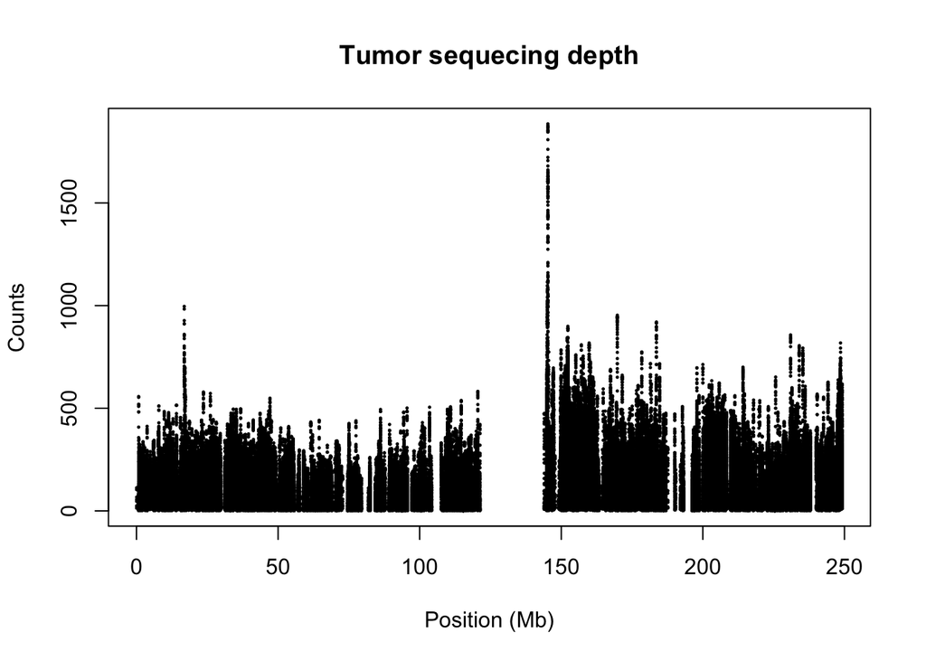

```r
dat.1$x = dat.1$position/1e6
plot(depth.tumor~x, dat.1, pch=20, cex=0.3, xlab="Position (Mb)", ylab="Counts", main="Tumor sequecing depth")
```

[figure not shown]

```r
plot(depth.tumor~x, dat.1, pch=20, cex=0.3, xlab="Position (Mb)", ylab="Counts", main="Germline sequecing depth")
```

If we compare the sequencing depths with the genomic GC, we see there is a strong bias.

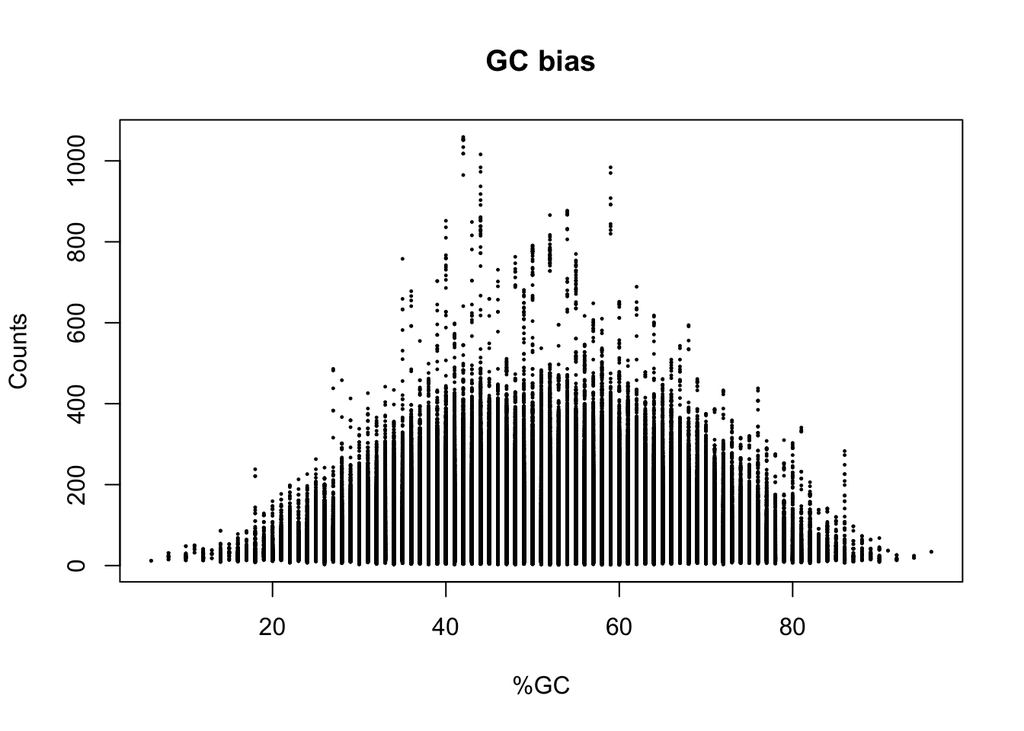

```r
plot(depth.normal~GC.percent, dat.1, pch=20, cex=0.3, xlab="%GC", ylab="Counts", main="GC bias")
```

This is still present after normalising using the germline sample.

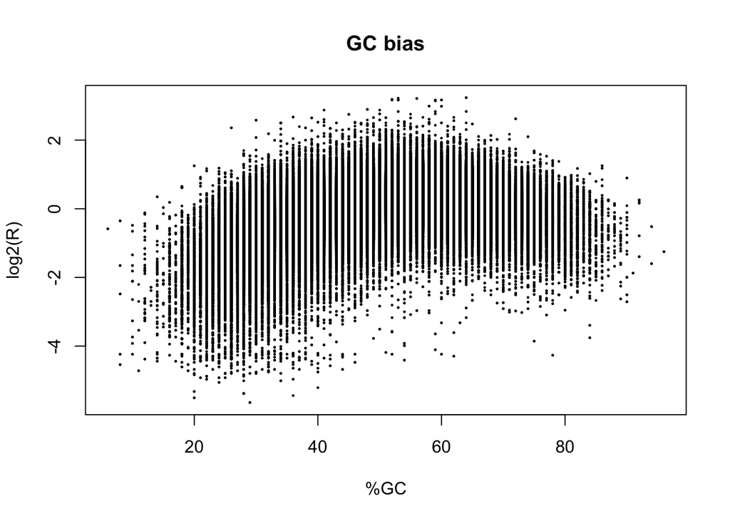

```r
plot(log2(depth.ratio)~GC.percent, dat.1, pch=20, cex=0.3, xlab="%GC", ylab="log2(R)", main="GC bias")
```

Finally, run the code in run_sequenza.R and explore the sequenza output